# GLM’s

Jorge de la Vega

27 de noviembre de 2018

## Ejemplos de Modelos lineales generalizados I

### Regresión logística

#### Estimación

Los siguientes datos son una muestra de un estudio de panel de la Dinámica de Ingreso (Mroz, T. (1987): ”The Sensitivity of an Empirical Model of Married Women’s Hours of Work to Economic and Statistical Assumptions,” *Econometrica*, Vol.55, 765-799.). La respuesta es la participación de las mujeres casadas en la fuerza laboral.

Las variables son:

- `lfp`: participación de la esposa en la fuerza laboral
- `k5`: número de niños menores a 5 años
- `k618`: número de niños de 6 a 18 años
- `age`: edad de la esposa
- `wc`: si la esposa asistió al colegio
- `hc`: si el esposo asistió al colegio
- `lwg`: logaritmo del salario estimado de la esposa. El logaritmo del salario estimado de la esposa se calcula como el logaritmo de su sueldo real si trabaja, y si no trabaja, entonces se imputa como el valor de predicción de una regresión de los logs de los salarios sobre los otros predictores para mujeres en la fuerza laboral.
- `inc`: ingreso de la familia excluyendo el ingreso de la esposa

```r
library(car) # paquete Companion to Applied Regression de Fox & Weisberg (2009)
data(Mroz)
str(Mroz)
```

```
'data.frame':   753 obs. of  8 variables:
 $ lfp : Factor w/ 2 levels "no","yes": 2 2 2 2 2 2 2 2 2 2 ...
 $ k5  : int  1 0 1 0 1 0 0 0 0 0 ...
 $ k618: int  0 2 3 3 2 0 2 0 2 2 ...
 $ age : int  32 30 35 34 31 54 37 54 48 39 ...
 $ wc  : Factor w/ 2 levels "no","yes": 1 1 1 1 2 1 2 1 1 1 ...
 $ hc  : Factor w/ 2 levels "no","yes": 1 1 1 1 1 1 1 1 1 1 ...
 $ lwg : num  1.2102 0.3285 1.5141 0.0921 1.5243 ...
 $ inc : num  10.9 19.5 12 6.8 20.1 ...
```

```r
head(Mroz)
```

```
  lfp k5 k618 age  wc hc       lwg    inc
1 yes  1    0  32  no no 1.2101647 10.910
2 yes  0    2  30  no no 0.3285041 19.500
3 yes  1    3  35  no no 1.5141279 12.040
4 yes  0    3  34  no no 0.0921151  6.800
5 yes  1    2  31 yes no 1.5242802 20.100
6 yes  0    0  54  no no 1.5564855  9.859
```

```r
# podemos cambiar link por probit, cloglog
mod1 <- glm(lfp ~ k5 + k618 + age + wc + hc + lwg + inc,
            family = binomial(link=probit), data = Mroz)
```

Los resultados se reportan de manera similar a los modelos de regresión lineal. En la salida se menciona que el parámetro de dispersión $\phi=1$.

Los `z-values` corresponden a las pruebas de Wald para cada coeficiente, y hace referencia a que la distribución de referencia para las pruebas es la distribución normal, y no la $t$ como en RLM.

La devianza nula y los grados de libertad corresponden al modelo que tiene sólo una constante.La devianza residual corresponde al modelo ajustado.

También se reporta el número de iteraciones en el método IWLS.

```r
summary(mod1)
```

```
Call:
glm(formula = lfp ~ k5 + k618 + age + wc + hc + lwg + inc, family = binomial(link = probit),
    data = Mroz)

Deviance Residuals:
    Min       1Q   Median       3Q      Max
-2.1359  -1.1024   0.5967   0.9746   2.2236

Coefficients:
             Estimate Std. Error z value Pr(>|z|)
(Intercept)  1.918418   0.382356   5.017 5.24e-07 ***
k5          -0.874712   0.114423  -7.645 2.10e-14 ***
k618        -0.038595   0.040950  -0.942 0.345942
age         -0.037824   0.007605  -4.973 6.58e-07 ***
wcyes        0.488310   0.136731   3.571 0.000355 ***
hcyes        0.057172   0.124207   0.460 0.645306
lwg          0.365635   0.089992   4.063 4.85e-05 ***
inc         -0.020525   0.004852  -4.230 2.34e-05 ***
---
Signif. codes:  0 '***' 0.001 '**' 0.01 '*' 0.05 '.' 0.1 ' ' 1

(Dispersion parameter for binomial family taken to be 1)

    Null deviance: 1029.75  on 752  degrees of freedom
Residual deviance:  905.39  on 745  degrees of freedom
AIC: 921.39

Number of Fisher Scoring iterations: 4
```

Podemos obtener los momios de éxito estimados:

$$\frac{\hat{\mu}({\bf x})}{1-\hat{\mu}({\bf x})} = \exp(b_0)\exp(b_1x_1)\cdots\exp(b_px_p)$$

Los exponentes de los coeficientes estimados se llaman *factores de riesgo*.

Para obtener todos los factores de riesgo y sus respectivos intervalos de confianza, podemos calcular lo siguiente:

```r
#la función confinit calcula intervalos usando la log-verosimilitud en lugar de Wald:
round(exp(cbind(Estimate = coef(mod1), confint(mod1))), 2)
```

```
            Estimate 2.5 % 97.5 %
(Intercept)     6.81  3.25  14.44
k5              0.42  0.33   0.52
k618            0.96  0.89   1.04
age             0.96  0.95   0.98
wcyes           1.63  1.25   2.13
hcyes           1.06  0.83   1.35
lwg             1.44  1.21   1.71
inc             0.98  0.97   0.99
```

#### Análisis de devianza

Para comparar modelos anidados como lo hacemos en los modelos lineales, usamos `anova`. Se compara el cambio en la desvianza y se compara contra $\chi^2_{(glG-glch)}$.

Por ejemplo, quitamos las variables de número de niños y colegio para el esposo y comparamos:

```r
mod2 <- update(mod1,. ~ . -k5 -k618 -hc)
summary(mod2)
```

```
Call:
glm(formula = lfp ~ age + wc + lwg + inc, family = binomial(link = probit),
    data = Mroz)

Deviance Residuals:
    Min       1Q   Median       3Q      Max
-1.8576  -1.1967   0.7086   1.0402   1.8472

Coefficients:
             Estimate Std. Error z value   Pr(>|z|)
(Intercept)  0.508201   0.273132   1.861   0.062794 .
age         -0.010528   0.005871  -1.793   0.072950 .
wcyes        0.408799   0.117002   3.494   0.000476 ***
lwg          0.379060   0.087474   4.333 0.00001468 ***
inc         -0.020011   0.004409  -4.538 0.00000567 ***
---
Signif. codes:  0 '***' 0.001 '**' 0.01 '*' 0.05 '.' 0.1 ' ' 1

(Dispersion parameter for binomial family taken to be 1)

    Null deviance: 1029.75  on 752  degrees of freedom
Residual deviance:  971.38  on 748  degrees of freedom
AIC: 981.38

Number of Fisher Scoring iterations: 4
```

```r
anova(mod2,mod1,test="Chisq") #primero el modelo chico y luego el grande.
```

```
Analysis of Deviance Table

Model 1: lfp ~ age + wc + lwg + inc
Model 2: lfp ~ k5 + k618 + age + wc + hc + lwg + inc
  Resid. Df Resid. Dev Df Deviance  Pr(>Chi)
1       748     971.38
2       745     905.39  3   65.985 3.087e-14 ***
---
Signif. codes:  0 '***' 0.001 '**' 0.01 '*' 0.05 '.' 0.1 ' ' 1
```

#### Valores ajustados

La función `predict` da predicciones para GLM’s. Los valores que devuelve por default son los valores ajustados:

```r
# Devuelve los valores ajustados, del predictor lineal:
head(predict(mod1))
```

```
          1           2           3           4           5           6
 0.05190218  0.42639462 -0.08940768  0.41074250  0.42707055  0.24269630
```

```r
# Devuelve las probabilidades ajustadas:
head(predict(mod1,type = "response"))
```

```
        1         2         3         4         5         6
0.5206967 0.6650898 0.4643790 0.6593693 0.6653360 0.5958797
```

Podemos obtener la curva logística ajustada:

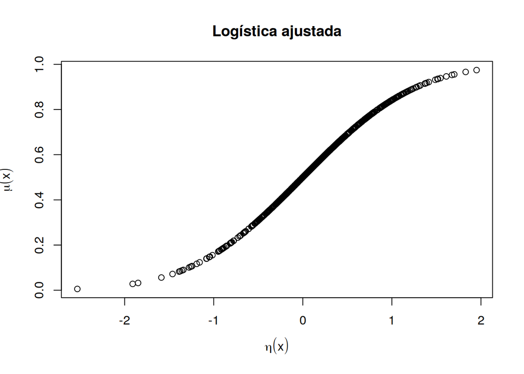

```r
plot(predict(mod1), predict(mod1,type = "response"),
     main= "Logística ajustada",
     xlab = expression(eta(x)),
     ylab = expression(mu(x)))
```

### Datos Binomiales

Para datos con respuesta binomial, se cuentan los éxitos en $N$ ensayos. Para especificar un modelo binomial en R se puede hacer de varias formas, como ya comentamos antes:

1. Una matriz con dos columnas con número de éxitos $Y$ y el número de fracasos $N-Y$.
2. La respuesta puede ser la proporción $Y/N$ especificando $N$ en `weights`

Sin importar cómo se especifique, `glm`considera como respuesta a la proporción de éxitos $Y/N$ y la media de la respuesta $\mu({\bf x})$ se interpreta igual que en el modelo binario.

Los siguientes datos corresponden a las votaciones de consultas populares de un nefasto presidente electo (ficticias):

```r
votaciones <- data.frame(
      colonia = factor(rep(c("BJ","IZ"),c(3,3))),
      preferencia = factor(rep(c("B","M","A"),2)),
      votaron = c(91,121,64,214,284,201),
      no.votaron = c(39,49,24,87,76,25),
      logit.votacion = log(c(91,121,64,214,284,201)/c(39,49,24,87,76,25)) )
votaciones
```

```
  colonia preferencia votaron no.votaron logit.votacion
1      BJ           B      91         39      0.8472979
2      BJ           M     121         49      0.9039702
3      BJ           A      64         24      0.9808293
4      IZ           B     214         87      0.9000679
5      IZ           M     284         76      1.3182409
6      IZ           A     201         25      2.0844291
```

También podemos ver los datos como una tabla de contingencia:

```r
 ftable(xtabs(
   cbind(votaron,no.votaron) ~ colonia + preferencia ,data=votaciones))
```

```
                     votaron no.votaron
colonia preferencia
BJ      A                 64         24
        B                 91         39
        M                121         49
IZ      A                201         25
        B                214         87
        M                284         76
```

Se puede ajustar este modelo agrupado, o se pueden descomponer todos los conteos en el número total de casos para ajustar un modelo logístico.

Ajustamos un modelo binomial con estas variables, considerando la interacción de la colonia y la preferencia. Noten que el modelo sólo tiene 6 datos y hay 6 parámetros a estimar, este es un ejemplo de un modelo saturado, por eso los residuales son 0:

```r
mod1 <- glm(cbind(votaron,no.votaron) ~ colonia*preferencia,
            family=binomial,data = votaciones)
summary(mod1)
```

```
Call:
glm(formula = cbind(votaron, no.votaron) ~ colonia * preferencia,
    family = binomial, data = votaciones)

Deviance Residuals:
[1]  0  0  0  0  0  0

Coefficients:
                       Estimate Std. Error z value  Pr(>|z|)
(Intercept)             0.98083    0.23936   4.098 0.0000417 ***
coloniaIZ               1.10360    0.31979   3.451  0.000559 ***
preferenciaB           -0.13353    0.30647  -0.436  0.663045
preferenciaM           -0.07686    0.29320  -0.262  0.793212
coloniaIZ:preferenciaB -1.05083    0.39378  -2.669  0.007618 **
coloniaIZ:preferenciaM -0.68933    0.38421  -1.794  0.072791 .
---
Signif. codes:  0 '***' 0.001 '**' 0.01 '*' 0.05 '.' 0.1 ' ' 1

(Dispersion parameter for binomial family taken to be 1)

    Null deviance: 3.4832e+01  on 5  degrees of freedom
Residual deviance: 4.8850e-14  on 0  degrees of freedom
AIC: 44.093

Number of Fisher Scoring iterations: 3
```

```r
# Todos los valores son exactamente los observados:
predict(mod1,type="link")
```

```
        1         2         3         4         5         6
0.8472979 0.9039702 0.9808293 0.9000679 1.3182409 2.0844291
```

Podemos quitar las interacciones:

```r
mod2 <- update(mod1,.~. - colonia:preferencia)
summary(mod2)
```

```
Call:
glm(formula = cbind(votaron, no.votaron) ~ colonia + preferencia,
    family = binomial, data = votaciones)

Deviance Residuals:
       1         2         3         4         5         6
 1.27448  -0.02845  -1.71962  -0.88628   0.02167   1.32305

Coefficients:
             Estimate Std. Error z value Pr(>|z|)
(Intercept)    1.4069     0.1814   7.756 8.75e-15 ***
coloniaIZ      0.4067     0.1401   2.903  0.00369 **
preferenciaB  -0.7998     0.1887  -4.239 2.24e-05 ***
preferenciaM  -0.4981     0.1867  -2.668  0.00764 **
---
Signif. codes:  0 '***' 0.001 '**' 0.01 '*' 0.05 '.' 0.1 ' ' 1

(Dispersion parameter for binomial family taken to be 1)

    Null deviance: 34.8319  on 5  degrees of freedom
Residual deviance:  7.1186  on 2  degrees of freedom
AIC: 47.212

Number of Fisher Scoring iterations: 4
```

### Modelos Poisson para conteo

Los modelos Poisson surgen en dos contextos diferentes:

1. Cuando se supone que la distribución condicional de la variable de respuesta dados los predictores es Poisson.
2. Cuando se analizan asociaciones en tablas de contingencia. En las tablas de contingencia, los conteos son multinomiales, no Poisson, condicionales, pero con una interpretación adecuada de los parámetros (condicionando los totales como ya vimos), los estimadores multinomiales se pueden obtener *como si* fueran los conteos Poisson.

Entonces se puede usar el mismo enfoque de modelos GLM se puede usar para regresión Poisson y para modelos loglineales de tablas de contingencia.

#### Estimación

Los siguientes datos (Ornstein, 1976) corresponden a datos de 248 empresas canadienses, en donde cada empresa tiene un cierto número de vínculos (interlocks): estos son empates que una empresa mantuvo en virtud de que los miembros de su Junta de Gobierno y ejecutivos top también sirven como miembros de Juntas o como ejecutivos top en otras empresas del conjunto de empresas que están en los datos.

Interesa hacer la regresión del número de vínculos con respecto a otras características de las empresas: sus activos, la nación controladora, y el sector de operación de la empresa.

```r
data("Ornstein")
str(Ornstein)
```

```
'data.frame':   248 obs. of  4 variables:
 $ assets    : int  147670 133000 113230 85418 75477 40742 40140 26866 24500 23700 ...
 $ sector    : Factor w/ 10 levels "AGR","BNK","CON",..: 2 2 2 2 2 4 9 2 9 8 ...
 $ nation    : Factor w/ 4 levels "CAN","OTH","UK",..: 1 1 1 1 1 1 1 1 1 4 ...
 $ interlocks: int  87 107 94 48 66 69 46 16 77 6 ...
```

Podemos ver la gráfica de la respuesta no condicional, hay 28 empresas sin vínculos, 19 con 1, 14 con 2, y así sucesivamente:

```r
vinculos <- xtabs(~ interlocks,data=Ornstein)
vinculos
```

```
interlocks
  0   1   2   3   4   5   6   7   8   9  10  11  12  13  14  15  16  17
 28  19  14  11   8  14  11   6  12   7   4  12   9   8   4   3   6   3
 18  19  20  21  22  23  25  27  28  29  30  31  32  33  34  35  36  39
  9   2   4   3   2   3   4   4   5   5   2   2   2   3   1   1   1   1
 40  42  43  44  46  48  51  55  66  69  77  87  94 107
  2   1   1   1   1   1   1   1   1   1   1   1   1   1
```

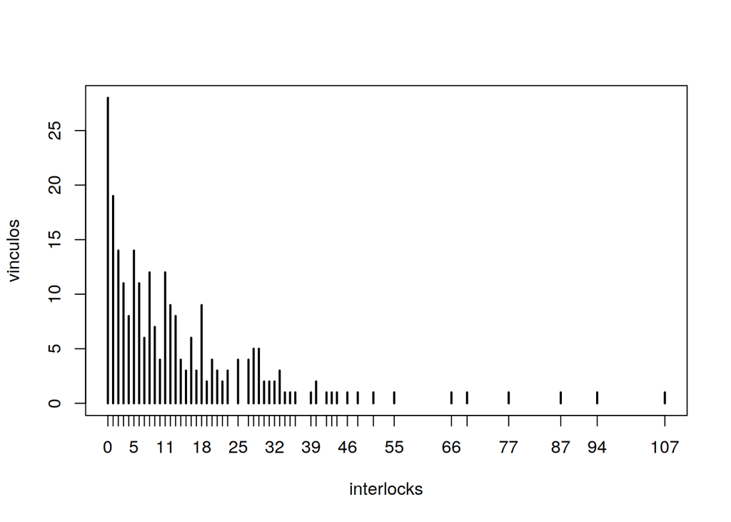

```r
plot(vinculos,type="h")
```

Podemos ajusta un modelo Poisson para estos datos:

```r
mod1 <- glm(interlocks ~ ., family = poisson, data = Ornstein)
summary(mod1)
```

```
Call:
glm(formula = interlocks ~ ., family = poisson, data = Ornstein)

Deviance Residuals:
    Min       1Q   Median       3Q      Max
-5.9908  -2.4767  -0.8582   1.3472   7.3610

Coefficients:
                Estimate   Std. Error z value Pr(>|z|)
(Intercept)  2.324579545  0.051932237  44.762  < 2e-16 ***
assets       0.000020851  0.000001202  17.340  < 2e-16 ***
sectorBNK   -0.409182044  0.155999161  -2.623  0.00872 **
sectorCON   -0.619570867  0.211968471  -2.923  0.00347 **
sectorFIN    0.676975305  0.068793189   9.841  < 2e-16 ***
sectorHLD    0.208460389  0.118869709   1.754  0.07948 .
sectorMAN    0.052598382  0.075534726   0.696  0.48621
sectorMER    0.177689947  0.086543931   2.053  0.04006 *
sectorMIN    0.621065819  0.066903896   9.283  < 2e-16 ***
sectorTRN    0.677828018  0.074825909   9.059  < 2e-16 ***
sectorWOD    0.711552438  0.075320411   9.447  < 2e-16 ***
nationOTH   -0.163206502  0.073618823  -2.217  0.02663 *
nationUK    -0.577086870  0.089028602  -6.482 9.05e-11 ***
nationUS    -0.825933451  0.048968411 -16.867  < 2e-16 ***
---
Signif. codes:  0 '***' 0.001 '**' 0.01 '*' 0.05 '.' 0.1 ' ' 1

(Dispersion parameter for poisson family taken to be 1)

    Null deviance: 3737.0  on 247  degrees of freedom
Residual deviance: 1887.4  on 234  degrees of freedom
AIC: 2813.4

Number of Fisher Scoring iterations: 5
```

Los coeficientes en este modelo se interpretan como efectos en la escala log del conteo, así que hay que exponenciar los coeficientes para producir los efectos multiplicativos en la escala de conteo:

```r
exp(coef(mod1))
```

```
(Intercept)      assets   sectorBNK   sectorCON   sectorFIN   sectorHLD
 10.2223811   1.0000209   0.6641933   0.5381753   1.9679164   1.2317801
  sectorMAN   sectorMER   sectorMIN   sectorTRN   sectorWOD   nationOTH
  1.0540063   1.1944549   1.8609104   1.9695952   2.0371514   0.8494158
   nationUK    nationUS
  0.5615318   0.4378261
```

Para ver los efectos, podemos usar el paquete `effects`.

- El eje vertical está en la escala del predictor lineal (logaritmo), pero las marcas son las etiquetas de la respuesta.

```r
library(effects)
```

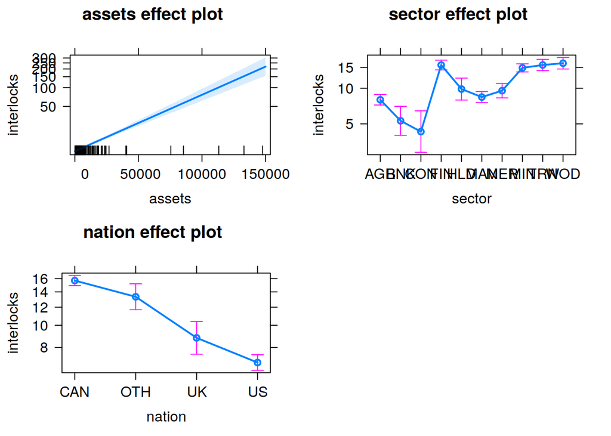

```r
plot(allEffects(mod1))
```

### Modelos loglineales para tablas de contingencia

Estos modelos fueron propuestos por Birch en 1963 (Maximum Likelihood in three-way contingency tables, JRSS,B, 25, 220-233).

#### Tablas de 2x2:

Consideremos primero una tabla de contingencia de $2 \times 2$, de todos los doctorados otorgados en ciencias matemáticas en los EUA en 2011:

```r
data("AMSsurvey")
head(AMSsurvey)
```

```
   type    sex citizen count count11
1 I(Pu)   Male      US   132     148
2 I(Pu) Female      US    35      40
3 I(Pr)   Male      US    87      63
4 I(Pr) Female      US    20      22
5    II   Male      US    96     161
6    II Female      US    47      53
```

Colapsando a una tabla donde sólo se tome `citizen` y `sex`:

```r
tabla <- xtabs(count11 ~ sex + citizen, data=AMSsurvey)
tabla
```

```
        citizen
sex      Non-US  US
  Female    276 219
  Male      575 574
```

El análisis típico en una tabla de dos dimensiones es probar independencia de renglones y columnas, usando una prueba de bondad de ajuste $\chi^2_{(r-1)(c-1)}$

```r
chisq.test(tabla, correct = F)
```

```
    Pearson's Chi-squared test

data:  tabla
X-squared = 4.5239, df = 1, p-value = 0.03342
```

Rechazamos la prueba de independencia entre renglones y columnas. Esto quiere decir que la proporción de mujeres es diferente para gringos y no gringos, o bien que la proporción de no gringos es diferente para hombres y mujeres.

Ajustando un modelo log-lineal: el modelo de independencia no incluye la interacción entre las variables.

```r
AMS <- as.data.frame(tabla)
AMS
```

```
     sex citizen Freq
1 Female  Non-US  276
2   Male  Non-US  575
3 Female      US  219
4   Male      US  574
```

```r
mod.indep <- glm(Freq ~ sex + citizen, family=poisson, data=AMS)
summary(mod.indep)
```

```
Call:
glm(formula = Freq ~ sex + citizen, family = poisson, data = AMS)

Deviance Residuals:
      1        2        3        4
 1.2196  -0.8151  -1.2976   0.8348

Coefficients:
            Estimate Std. Error z value Pr(>|z|)
(Intercept)  5.54608    0.05086  109.04   <2e-16 ***
sexMale      0.84209    0.05376   15.66   <2e-16 ***
citizenUS   -0.07059    0.04936   -1.43    0.153
---
Signif. codes:  0 '***' 0.001 '**' 0.01 '*' 0.05 '.' 0.1 ' ' 1

(Dispersion parameter for poisson family taken to be 1)

    Null deviance: 274.0843  on 3  degrees of freedom
Residual deviance:   4.5324  on 1  degrees of freedom
AIC: 41.602

Number of Fisher Scoring iterations: 3
```

La devianza residual es 4.5324, que es la diferencia entre el modelo ajustado y el modelo saturado. Este valor es una prueba de que la asociación entre sexo y ciudadadanía es 0. Podemos calcular su significancia:

```r
pchisq(4.5324, df=1, lower.tail = F)
```

```
[1] 0.03325894
```

#### Tablas de 3x3:

Incorporando el tipo de institución (`type` se refiere a grupos I para universidades públicas y privadas respectivamente, II y III para grupos II y III, IV para estadística y bioestadística y Va para matemáticas aplicadas), hay muchos más modelos que pueden ser considerados: con factores simples, interacciones de dos y tres variables.

```r
tabla <- ftable(xtabs(count11 ~ type + sex + citizen, data=AMSsurvey))
tabla
```

```
             citizen Non-US  US
type  sex
I(Pr) Female             26  22
      Male               82  63
I(Pu) Female             32  40
      Male              136 148
II    Female             56  53
      Male              116 161
III   Female             30  28
      Male               61  71
IV    Female            115  55
      Male              153  89
Va    Female             17  21
      Male               27  42
```

Para plantear modelos razonables, se debe cumplir el *Principio de marginalidad*: Un modelo que incluye un término de orden alto (como interacciones) también debe incluir los predictires relativos de menor orden de ese término: los efectos principales que componen la interacción.

El modelo más grande es el modelo saturado, y a partir de este se pueden considerar modelos menores eliminando términos, pero cumpliendo el principio de marginalidad. Por ejemplo, podemos ejecutar los modelos en el orden siguiente:

```r
mod.saturado <- glm(count ~ type*sex*citizen, family=poisson, data=AMSsurvey)
```

A partir del modelo saturado, podemos usar `Anova` para calcular todas las pruebas de modelos conformando el principio de marginalidad (usualmente se llaman pruebas tipo II)

```r
Anova(mod.saturado)
```

```
Analysis of Deviance Table (Type II tests)

Response: count
                 LR Chisq Df Pr(>Chisq)
type              233.336  5  < 2.2e-16 ***
sex               182.983  1  < 2.2e-16 ***
citizen             5.923  1  0.0149447 *
type:sex           69.135  5  1.551e-13 ***
type:citizen       24.041  5  0.0002132 ***
sex:citizen         0.538  1  0.4634559
type:sex:citizen    1.419  5  0.9221984
---
Signif. codes:  0 '***' 0.001 '**' 0.01 '*' 0.05 '.' 0.1 ' ' 1
```

- La tabla se tiene que leer de abajo hacia arriba. La triple interacción y la interacción de `sex:citizen` no son significativas, las otras son diferentes de 0.
- La prueba de los efectos principales usualmente son irrelevantes, pues corresponden a las marginales de las variables.

Si actualizamos el modelo quitando los dos últimos términos que no fueron significativos:

```r
mod.1 <- update(mod.saturado, .~ . -sex:citizen - type:sex:citizen)
summary(mod.1)
```

```
Call:
glm(formula = count ~ type + sex + citizen + type:sex + type:citizen,
    family = poisson, data = AMSsurvey)

Deviance Residuals:
     Min        1Q    Median        3Q       Max
-0.60314  -0.22365  -0.00152   0.22934   0.58670

Coefficients:
                       Estimate  Std. Error z value Pr(>|z|)
(Intercept)          3.09919526  0.16461552  18.827  < 2e-16 ***
typeI(Pu)            0.34169465  0.21434807   1.594 0.110911
typeII               0.76808259  0.20262205   3.791 0.000150 ***
typeIII              0.54360964  0.21495206   2.529 0.011439 *
typeIV               1.53102779  0.18695442   8.189 2.63e-16 ***
typeVa              -0.62955608  0.28141815  -2.237 0.025281 *
sexMale              1.30532530  0.16806641   7.767 8.05e-15 ***
citizenUS            0.02843794  0.13769960   0.207 0.836384
typeI(Pu):sexMale    0.10413612  0.21837608   0.477 0.633458
typeII:sexMale      -0.65968045  0.20966879  -3.146 0.001654 **
typeIII:sexMale     -0.96283499  0.22875932  -4.209 2.57e-05 ***
typeIV:sexMale      -1.11153931  0.19929118  -5.577 2.44e-08 ***
typeVa:sexMale      -0.43628745  0.28781398  -1.516 0.129553
typeI(Pu):citizenUS  0.02065167  0.17674420   0.117 0.906983
typeII:citizenUS    -0.00006724  0.18206710   0.000 0.999705
typeIII:citizenUS   -0.18077866  0.20612853  -0.877 0.380476
typeIV:citizenUS    -0.62507422  0.17710580  -3.529 0.000417 ***
typeVa:citizenUS     0.15388362  0.25454766   0.605 0.545486
---
Signif. codes:  0 '***' 0.001 '**' 0.01 '*' 0.05 '.' 0.1 ' ' 1

(Dispersion parameter for poisson family taken to be 1)

    Null deviance: 521.4440  on 23  degrees of freedom
Residual deviance:   1.9568  on  6  degrees of freedom
AIC: 175.35

Number of Fisher Scoring iterations: 4
```

La prueba para la devianza residual es

```r
pchisq(1.9568,df=6,lower.tail = F)
```

```
[1] 0.9236285
```

Esto quiere decir que no hay diferencia entre el modelo saturado y el ajustado, y por lo tanto el modelo ajusta muy bien los datos.

#### Planes de muestreo para modelos loglineales

En general las tablas de contingencia se pueden construir de diferentes modos, pero en todos los casos el modelo Poisson puede ser usado:

1. *Muestreo Poisson*: Tamaño de muestra total aleatorio $n$.
2. *Muestreo Multinomial*: Se fija el tamaño de muestra total de antemano $n$ y se muestrea en las diferentes celdas hasta alcanzar el tamaño de muestra. En este caso los conteos no son independientes por la restricción de que suman $n$. En este caso la media total queda determinada por el plan de muestreo (la ordenada al origen).
3. *Muestreo producto-multinomial*: se muestrea tomando igual número de observaciones en alguna de las dimensiones. En este caso, la ordenada al origen y los efectos principales están determinados por el muestreo.
4. *Muestreo fijando dos niveles*: Se muestrea un número fijo en cada combinación de dos dimensiones, para obtener esquemas de muestreo multinomiales en esas dos dimensiones. En este caso, todos los modelos que se ajusten deben contener los términos `1 + A + B + A:B = A*B`, porque están fijos por el diseño muestral.
5. *Muestreo retrospectivo (o de control de casos)*: Supongamos que una de las dimensiones $C$ del problema tiene categorías que ocurren de manera rara. Podemos decidir muestrar $n/2$ eventos raros de $C$ y el resto de los no raros. Entonces $C$ funge como una variable de respuesta. Estos modelos deben incluir `1 + C`. Los otros términos del modelo en donde aparece $C$ nos dicen si la respuesta está relacionada con los predictores, y de qué manera.